# Canada’s Economy

February 26, 2017

## Motivation

- How do events translate into metrics?
- How do current events translate?
- What are some interesting questions?

## Tools

- Exploratory Data Analysis
  - Define expectations
  - Plot data
  - Check expectations
- Outcomes:
  - Refine expectations when needed
  - Find insights where expectations aren't met
  - Define analomalies
- John W. Tukey - Exploratory Data Analysis, 1977

## Context

- 21st Century: 2000 - Present
- Data Sources
  - CANSIM
  - Statistics Canada
  - Provincial Goverments
  - IBIS World
- Factors
  - GDP
  - Demographics
  - Employment
  - CPI
  - Trade

## Key Dichotomies (Findings)

- Unemployment:
  - Western vs Eastern Canada
- Bad Effects :
  - 2015 Oil Slump vs 2008 Recession
- Trade :
  - Ontario vs Alberta

## Open Questions

- Decline of Goods production stopped by recession?
- Pharamaceuticals, lower investment = same growth rates?
- Gold and Silver, major export - accomplices?
- What triggered workforce aging?

## GDP Centers

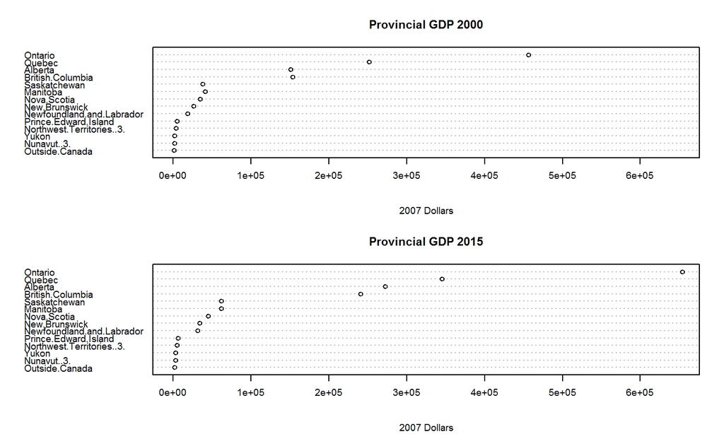

## GDP Centers

- 1995 - 2008 Steady GDP Growth
- Resource Boom
  - Alberta, Saskatchewan, and Newfoundland & Labrador
- Manufacuring Declines
  - Employment in Ontario 15.8% (2000) versus 10.3% (2011)
  - Automation
  - "Global Value Chain"
  - China

https://mowatcentre.ca/how-ontario-lost-300000-manufacturing-jobs/

https://www.fraserinstitute.org/sites/default/files/federal-fiscal-history-canada-1867-2017.pdf

## GDP Centers

- Why Ontario?
  - 20th Century
    - Canada-United States Automotive Pact
    - NAFTA
    - Correlation To US
  - 21st Century
    - Public Spending
    - Immagration

https://www.fraserinstitute.org/sites/default/files/can-canada-prosper-without-a-prosperous-ontario-rev.pdf

## Employment Shifts

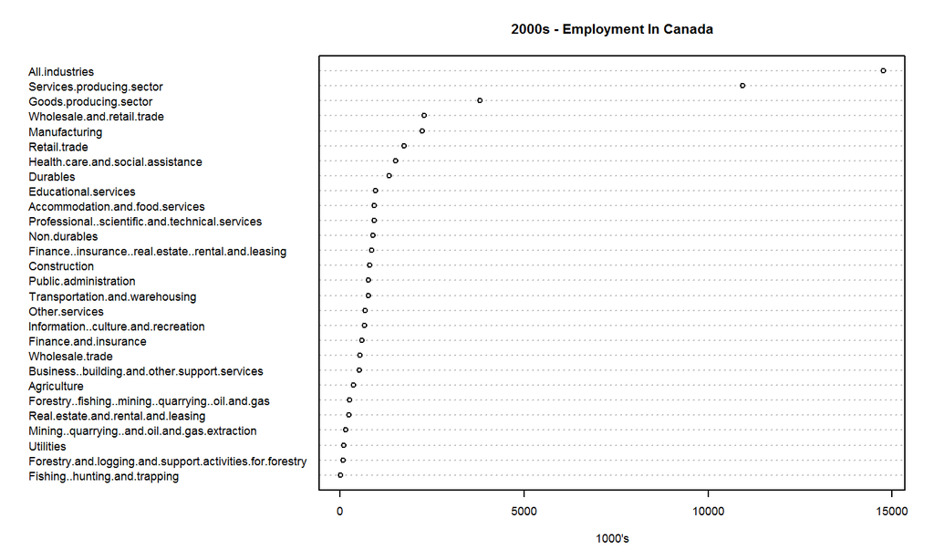

## Employment Shifts

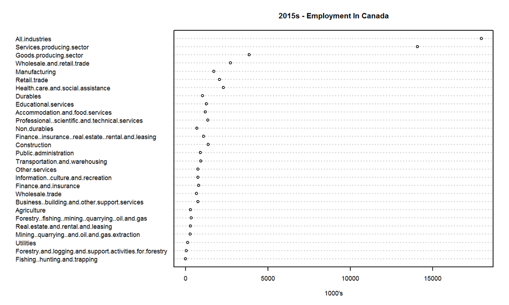

## Employment Shifts

- "For every job that has been lost in the goods sector since 2001, about 30 jobs have been created in service industries"
- Services as a diverse label
  - Engineering
  - Banking
  - IT services
- Things In Common
  - Demand in sophisticated professional services
  - Remote Services, Stantec in Edmonton: 1/2 revenues outside Canadad
  - EM Emerging middle class requires skills found elsewhere.

http://www.macleans.ca/economy/economicanalysis/the-services-industry-canadas-secret-economic-playground/

http://www.bankofcanada.ca/2016/11/growth-service-sector-helping-canadas-economy/

## Population growth != GDP growth

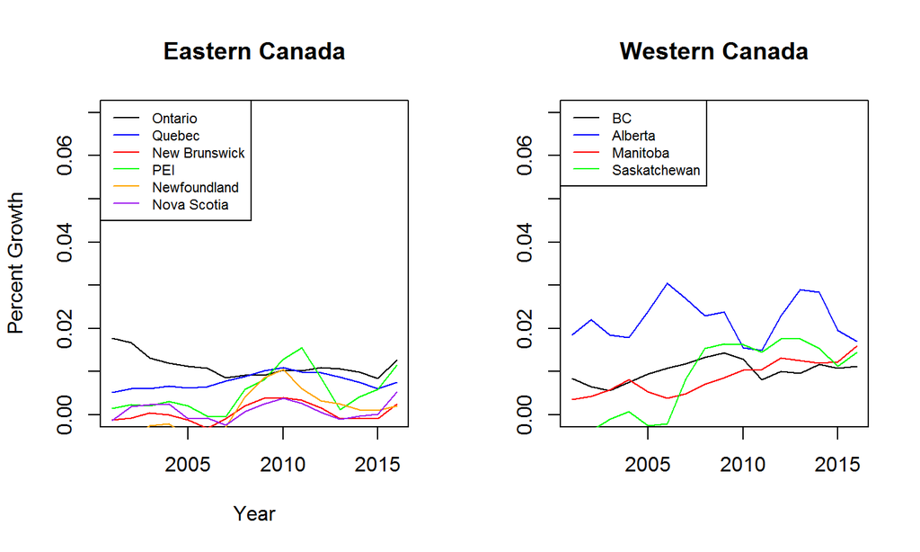

## Population growth > 1/3 Immigration

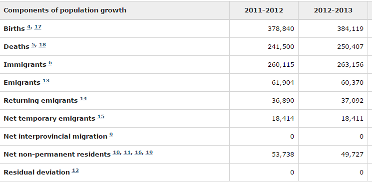

## On Immigration

- 9/11 Effects, Immigration and Refugee Protection Act
- In Spite, Canada is recognized as one of the most open immigration countries in the world.

http://www.thecanadianencyclopedia.ca/en/article/immigration/

## Workforce Aging

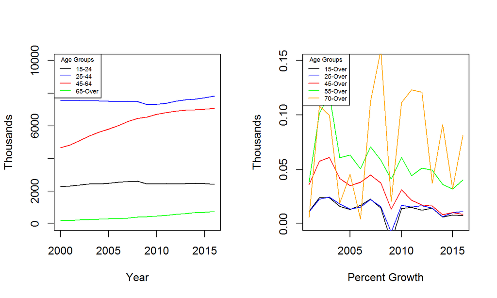

## Workforce Aging

- Shift in growth eariler 2000's
- Long Life Spans?
- Baby Boomer Effect?
- Costlier Retirement?
- Consecquences
  - An "Age Cliff"
  - Productivity Effects?
  - Expansionary Effects?

http://www.theglobeandmail.com/globe-investor/retirement/the-boomer-shift-how-canadas-economy-is-headed-for-majorchange/article27159892/

## Unemployment: Western vs Eastern Canada

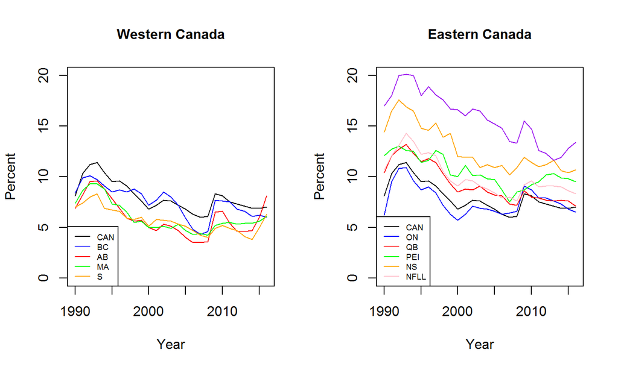

## Unemployment:

- Eastern Canada
  - Higher Systemic Unemployment
  - Large Population Centres alright though
  - Decline in Manufacturing
- Western Canada
  - Lowever systemic unemployment
  - 2008 verus Oil Slump effects
  - Boom in natural resources

## 2015 Oil Slump vs 2008 Recession

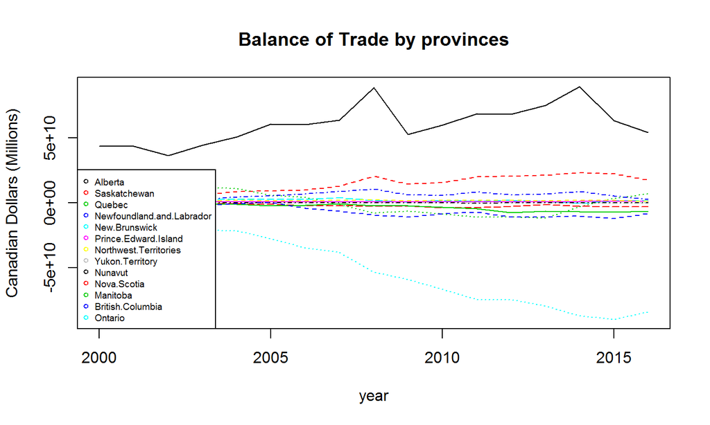

## 2015 Oil Slump vs 2008 Recession

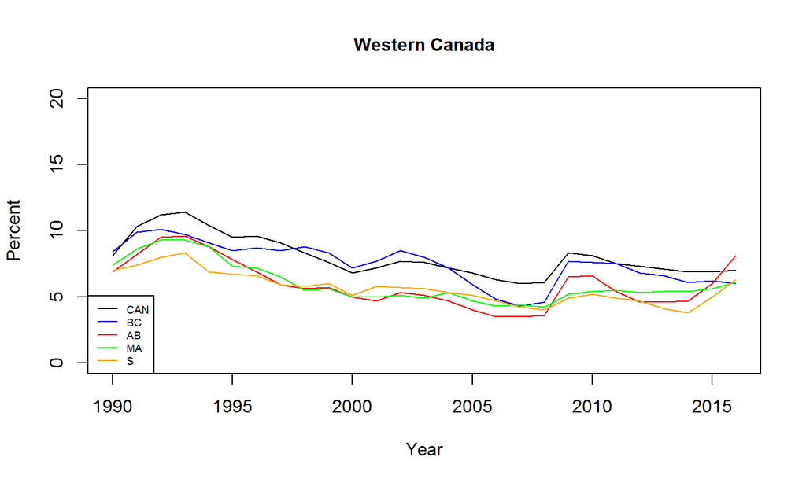

## 2015 Oil Slump vs 2008 Recession

- Export Effects?
- Employment Effects?

## Trade: Ontario vs Alberta

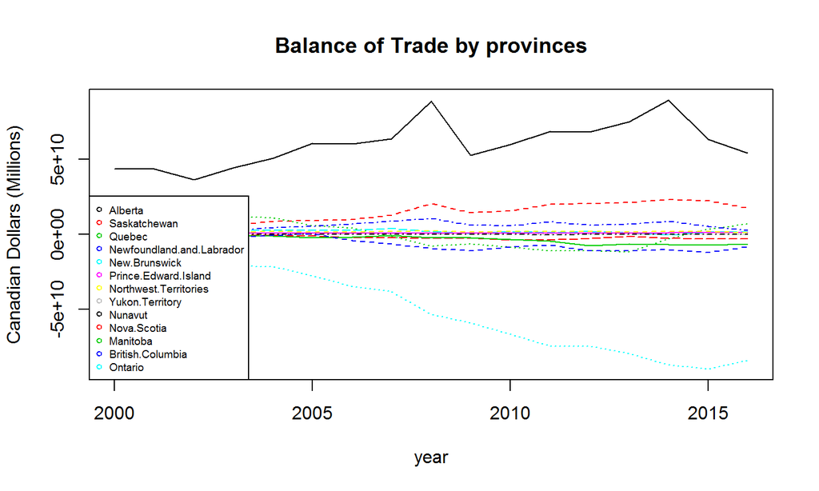